# 14_oblique_projection

## 14_oblique_projection

#### Question

1. One of the simplest 3D $\to$ 2D projections (to draw by hand) is an [oblique projection](https://en.wikipedia.org/wiki/Oblique_projection). Each type of oblique projection can be parameterized with an angle ($\theta$) and a ratio ($r<1$). Below is an oblique-projection matrix.

   $$P = \begin{bmatrix}1 & r\cos(\theta_P) & 0 \\ 0 & r\sin(\theta_P) & 1 \end{bmatrix}$$

   We can exemplify an oblique projection with $r=0.5$ and $\theta_P=\frac{pi}{6}$ on a unit cube. The cube has lengths 1 unit long.

   (SageMath)

   ```
   X = matrix([[0,0,0,0,0,1,1,0,1,1,0,1,1,0,1,1],[0,0,1,1,0,0,1,1,1,1,1,1,0,0,0,0],[0,1,1,0,0,0,0,0,0,1,1,1,1,1,1,0]])
   r = 0.5
   tp = pi/6
   P = matrix([[1,r*cos(tp),0],[0,r*sin(tp),1]])
   flat_X = P*X
   line(flat_X.transpose(),aspect_ratio=1)
   ```

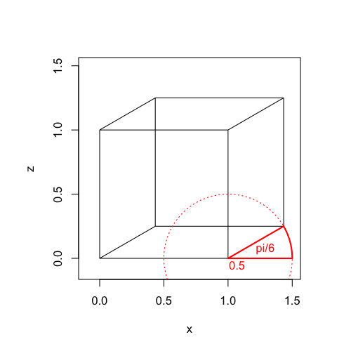

   In 3D, there are relatively simple rotation matrices for spinning around the $x$, $y$, or $z$ axis.

   $$R_x = \begin{bmatrix}1 & 0 & 0 \\ 0 & \cos(\theta_x) & -\sin(\theta_x) \\ 0 &\sin(\theta_x) & \cos(\theta_x) \end{bmatrix}$$

   $$R_y = \begin{bmatrix}\cos(\theta_y) & 0 & \sin(\theta_y) \\ 0 & 1 & 0 \\ -\sin(\theta_y) & 0 & \cos(\theta_y) \end{bmatrix}$$

   $$R_z = \begin{bmatrix}\cos(\theta_z) & -\sin(\theta_z) & 0 \\ \sin(\theta_z) & \cos(\theta_z) & 0 \\ 0 & 0 & 1\end{bmatrix}$$

## Information specific to this question

   Fill in the missing code to generate various rotations of a square pyramid.
   - Red: X1 is the original
   - Orange: X2 is after a rotation of 1.72 radians around the x-axis
   - Green: X3 has another rotation of 2.36 radians around the y-axis
   - Blue: X4 has another rotation of 3.58 radians around the z-axis

   In order to flatten the 3D points onto a 2D graph, each pyramid will undergo an oblique projection with $r=0.14$ and $\theta_P=0.72$.

   ```
   graph01 = Graphics()
   X1 = matrix([[1,-1,-1,1,1,0,1,-1,0,-1],[-1,-1,1,1,-1,0,1,1,0,-1],[-1,-1,-1,-1,-1,1,-1,-1,1,-1]])
   P = ...
   X1_flat = ...
   graph01 += line(X1_flat.transpose(),color="red")
   Rx = ...
   X2 = ...
   X2_flat = ...
   graph01 += line(X2_flat.transpose(),color="orange")
   Ry = ...
   X3 = ...
   X3_flat = ...
   graph01 += ...
   Rz = ...
   X4 = ...
   X4_flat = ...
   graph01 += ...
   show(graph01,aspect_ratio=1,axes=False)
   ```

   Which graph matches?

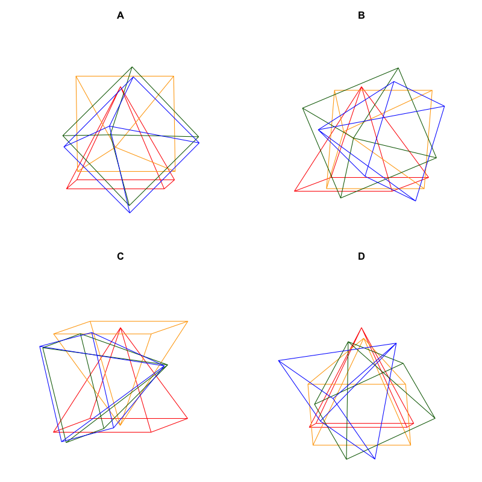

   1. A
   2. B
   3. C
   4. D

#### Question

2. One of the simplest 3D $\to$ 2D projections (to draw by hand) is an [oblique projection](https://en.wikipedia.org/wiki/Oblique_projection). Each type of oblique projection can be parameterized with an angle ($\theta$) and a ratio ($r<1$). Below is an oblique-projection matrix.

   $$P = \begin{bmatrix}1 & r\cos(\theta_P) & 0 \\ 0 & r\sin(\theta_P) & 1 \end{bmatrix}$$

   We can exemplify an oblique projection with $r=0.5$ and $\theta_P=\frac{pi}{6}$ on a unit cube. The cube has lengths 1 unit long.

   (SageMath)

   ```
   X = matrix([[0,0,0,0,0,1,1,0,1,1,0,1,1,0,1,1],[0,0,1,1,0,0,1,1,1,1,1,1,0,0,0,0],[0,1,1,0,0,0,0,0,0,1,1,1,1,1,1,0]])
   r = 0.5
   tp = pi/6
   P = matrix([[1,r*cos(tp),0],[0,r*sin(tp),1]])
   flat_X = P*X
   line(flat_X.transpose(),aspect_ratio=1)
   ```

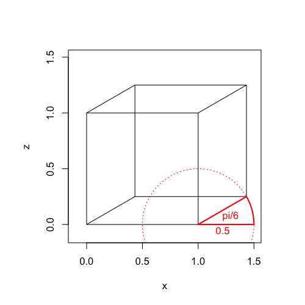

   In 3D, there are relatively simple rotation matrices for spinning around the $x$, $y$, or $z$ axis.

   $$R_x = \begin{bmatrix}1 & 0 & 0 \\ 0 & \cos(\theta_x) & -\sin(\theta_x) \\ 0 &\sin(\theta_x) & \cos(\theta_x) \end{bmatrix}$$

   $$R_y = \begin{bmatrix}\cos(\theta_y) & 0 & \sin(\theta_y) \\ 0 & 1 & 0 \\ -\sin(\theta_y) & 0 & \cos(\theta_y) \end{bmatrix}$$

   $$R_z = \begin{bmatrix}\cos(\theta_z) & -\sin(\theta_z) & 0 \\ \sin(\theta_z) & \cos(\theta_z) & 0 \\ 0 & 0 & 1\end{bmatrix}$$

## Information specific to this question

   Fill in the missing code to generate various rotations of a square pyramid.
   - Red: X1 is the original
   - Orange: X2 is after a rotation of 1.73 radians around the x-axis
   - Green: X3 has another rotation of 2.45 radians around the y-axis
   - Blue: X4 has another rotation of 0.18 radians around the z-axis

   In order to flatten the 3D points onto a 2D graph, each pyramid will undergo an oblique projection with $r=0.44$ and $\theta_P=0.36$.

   ```
   graph01 = Graphics()
   X1 = matrix([[1,-1,-1,1,1,0,1,-1,0,-1],[-1,-1,1,1,-1,0,1,1,0,-1],[-1,-1,-1,-1,-1,1,-1,-1,1,-1]])
   P = ...
   X1_flat = ...
   graph01 += line(X1_flat.transpose(),color="red")
   Rx = ...
   X2 = ...
   X2_flat = ...
   graph01 += line(X2_flat.transpose(),color="orange")
   Ry = ...
   X3 = ...
   X3_flat = ...
   graph01 += ...
   Rz = ...
   X4 = ...
   X4_flat = ...
   graph01 += ...
   show(graph01,aspect_ratio=1,axes=False)
   ```

   Which graph matches?

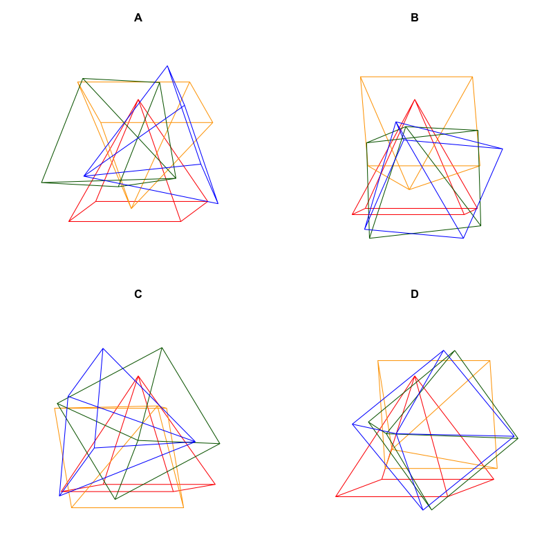

   1. A
   2. B
   3. C
   4. D

#### Question

3. One of the simplest 3D $\to$ 2D projections (to draw by hand) is an [oblique projection](https://en.wikipedia.org/wiki/Oblique_projection). Each type of oblique projection can be parameterized with an angle ($\theta$) and a ratio ($r<1$). Below is an oblique-projection matrix.

   $$P = \begin{bmatrix}1 & r\cos(\theta_P) & 0 \\ 0 & r\sin(\theta_P) & 1 \end{bmatrix}$$

   We can exemplify an oblique projection with $r=0.5$ and $\theta_P=\frac{pi}{6}$ on a unit cube. The cube has lengths 1 unit long.

   (SageMath)

   ```
   X = matrix([[0,0,0,0,0,1,1,0,1,1,0,1,1,0,1,1],[0,0,1,1,0,0,1,1,1,1,1,1,0,0,0,0],[0,1,1,0,0,0,0,0,0,1,1,1,1,1,1,0]])
   r = 0.5
   tp = pi/6
   P = matrix([[1,r*cos(tp),0],[0,r*sin(tp),1]])
   flat_X = P*X
   line(flat_X.transpose(),aspect_ratio=1)
   ```

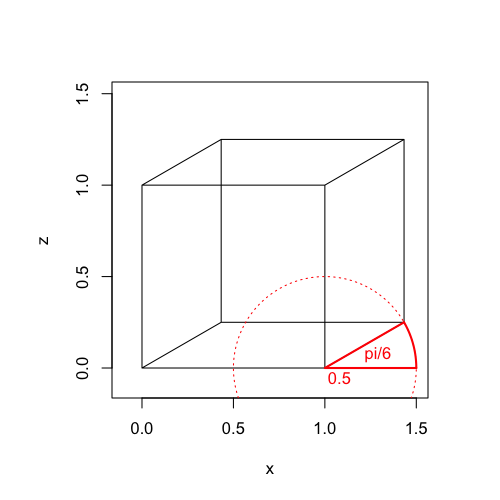

   In 3D, there are relatively simple rotation matrices for spinning around the $x$, $y$, or $z$ axis.

   $$R_x = \begin{bmatrix}1 & 0 & 0 \\ 0 & \cos(\theta_x) & -\sin(\theta_x) \\ 0 &\sin(\theta_x) & \cos(\theta_x) \end{bmatrix}$$

   $$R_y = \begin{bmatrix}\cos(\theta_y) & 0 & \sin(\theta_y) \\ 0 & 1 & 0 \\ -\sin(\theta_y) & 0 & \cos(\theta_y) \end{bmatrix}$$

   $$R_z = \begin{bmatrix}\cos(\theta_z) & -\sin(\theta_z) & 0 \\ \sin(\theta_z) & \cos(\theta_z) & 0 \\ 0 & 0 & 1\end{bmatrix}$$

## Information specific to this question

   Fill in the missing code to generate various rotations of a square pyramid.
   - Red: X1 is the original
   - Orange: X2 is after a rotation of 4.31 radians around the x-axis
   - Green: X3 has another rotation of 3.01 radians around the y-axis
   - Blue: X4 has another rotation of 5.34 radians around the z-axis

   In order to flatten the 3D points onto a 2D graph, each pyramid will undergo an oblique projection with $r=0.16$ and $\theta_P=0.4$.

   ```
   graph01 = Graphics()
   X1 = matrix([[1,-1,-1,1,1,0,1,-1,0,-1],[-1,-1,1,1,-1,0,1,1,0,-1],[-1,-1,-1,-1,-1,1,-1,-1,1,-1]])
   P = ...
   X1_flat = ...
   graph01 += line(X1_flat.transpose(),color="red")
   Rx = ...
   X2 = ...
   X2_flat = ...
   graph01 += line(X2_flat.transpose(),color="orange")
   Ry = ...
   X3 = ...
   X3_flat = ...
   graph01 += ...
   Rz = ...
   X4 = ...
   X4_flat = ...
   graph01 += ...
   show(graph01,aspect_ratio=1,axes=False)
   ```

   Which graph matches?

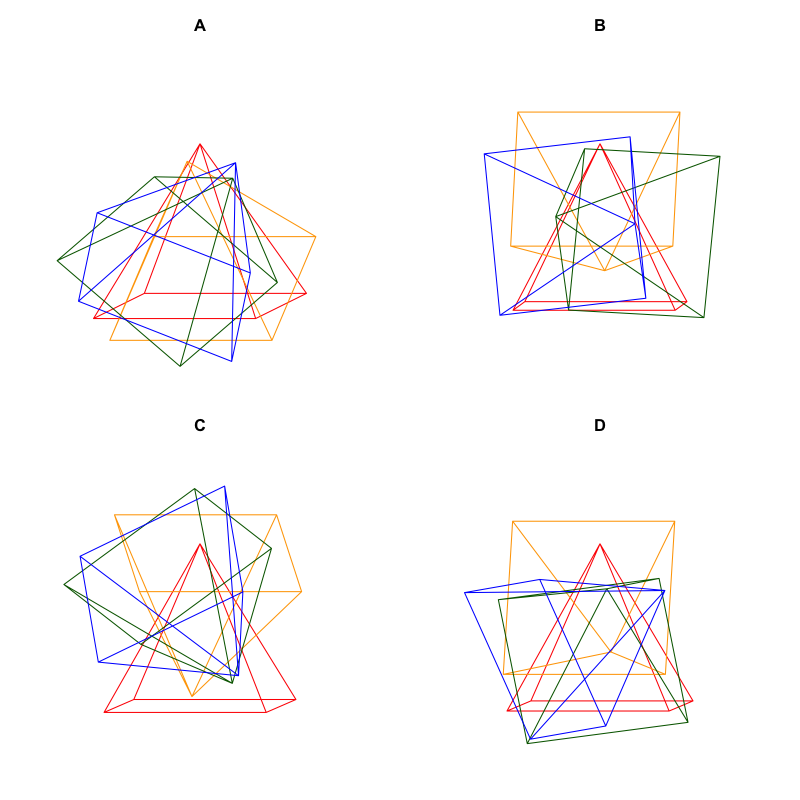

   1. A
   2. B
   3. C
   4. D

#### Question

4. One of the simplest 3D $\to$ 2D projections (to draw by hand) is an [oblique projection](https://en.wikipedia.org/wiki/Oblique_projection). Each type of oblique projection can be parameterized with an angle ($\theta$) and a ratio ($r<1$). Below is an oblique-projection matrix.

   $$P = \begin{bmatrix}1 & r\cos(\theta_P) & 0 \\ 0 & r\sin(\theta_P) & 1 \end{bmatrix}$$

   We can exemplify an oblique projection with $r=0.5$ and $\theta_P=\frac{pi}{6}$ on a unit cube. The cube has lengths 1 unit long.

   (SageMath)

   ```
   X = matrix([[0,0,0,0,0,1,1,0,1,1,0,1,1,0,1,1],[0,0,1,1,0,0,1,1,1,1,1,1,0,0,0,0],[0,1,1,0,0,0,0,0,0,1,1,1,1,1,1,0]])
   r = 0.5
   tp = pi/6
   P = matrix([[1,r*cos(tp),0],[0,r*sin(tp),1]])
   flat_X = P*X
   line(flat_X.transpose(),aspect_ratio=1)
   ```

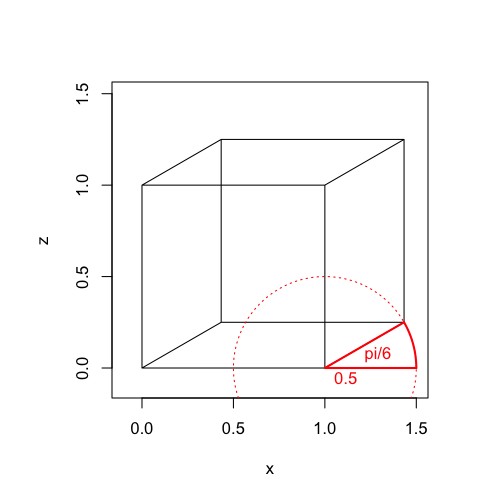

   In 3D, there are relatively simple rotation matrices for spinning around the $x$, $y$, or $z$ axis.

   $$R_x = \begin{bmatrix}1 & 0 & 0 \\ 0 & \cos(\theta_x) & -\sin(\theta_x) \\ 0 &\sin(\theta_x) & \cos(\theta_x) \end{bmatrix}$$

   $$R_y = \begin{bmatrix}\cos(\theta_y) & 0 & \sin(\theta_y) \\ 0 & 1 & 0 \\ -\sin(\theta_y) & 0 & \cos(\theta_y) \end{bmatrix}$$

   $$R_z = \begin{bmatrix}\cos(\theta_z) & -\sin(\theta_z) & 0 \\ \sin(\theta_z) & \cos(\theta_z) & 0 \\ 0 & 0 & 1\end{bmatrix}$$

## Information specific to this question

   Fill in the missing code to generate various rotations of a square pyramid.
   - Red: X1 is the original
   - Orange: X2 is after a rotation of 2.13 radians around the x-axis
   - Green: X3 has another rotation of 3 radians around the y-axis
   - Blue: X4 has another rotation of 5.53 radians around the z-axis

   In order to flatten the 3D points onto a 2D graph, each pyramid will undergo an oblique projection with $r=0.23$ and $\theta_P=0.69$.

   ```
   graph01 = Graphics()
   X1 = matrix([[1,-1,-1,1,1,0,1,-1,0,-1],[-1,-1,1,1,-1,0,1,1,0,-1],[-1,-1,-1,-1,-1,1,-1,-1,1,-1]])
   P = ...
   X1_flat = ...
   graph01 += line(X1_flat.transpose(),color="red")
   Rx = ...
   X2 = ...
   X2_flat = ...
   graph01 += line(X2_flat.transpose(),color="orange")
   Ry = ...
   X3 = ...
   X3_flat = ...
   graph01 += ...
   Rz = ...
   X4 = ...
   X4_flat = ...
   graph01 += ...
   show(graph01,aspect_ratio=1,axes=False)
   ```

   Which graph matches?

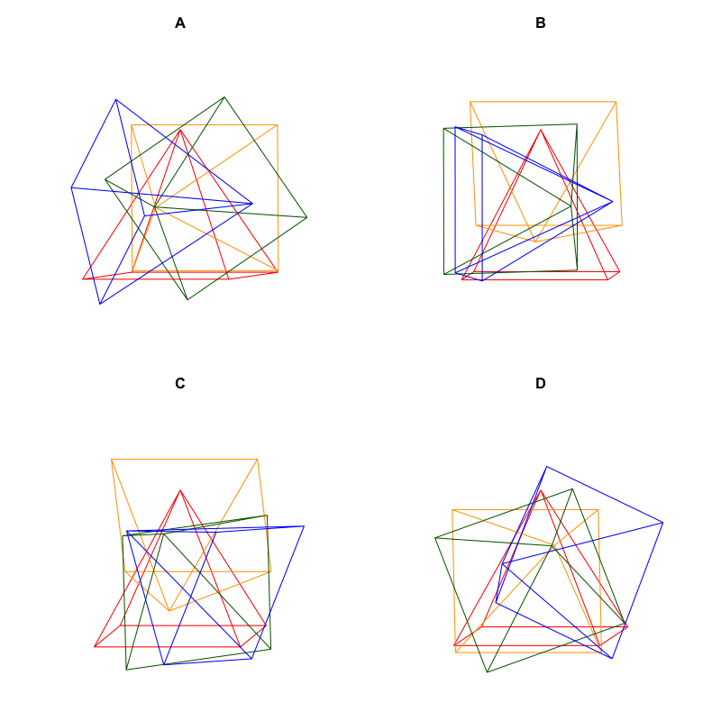

   1. A
   2. B
   3. C
   4. D

#### Question

5. One of the simplest 3D $\to$ 2D projections (to draw by hand) is an [oblique projection](https://en.wikipedia.org/wiki/Oblique_projection). Each type of oblique projection can be parameterized with an angle ($\theta$) and a ratio ($r<1$). Below is an oblique-projection matrix.

   $$P = \begin{bmatrix}1 & r\cos(\theta_P) & 0 \\ 0 & r\sin(\theta_P) & 1 \end{bmatrix}$$

   We can exemplify an oblique projection with $r=0.5$ and $\theta_P=\frac{pi}{6}$ on a unit cube. The cube has lengths 1 unit long.

   (SageMath)

   ```
   X = matrix([[0,0,0,0,0,1,1,0,1,1,0,1,1,0,1,1],[0,0,1,1,0,0,1,1,1,1,1,1,0,0,0,0],[0,1,1,0,0,0,0,0,0,1,1,1,1,1,1,0]])
   r = 0.5
   tp = pi/6
   P = matrix([[1,r*cos(tp),0],[0,r*sin(tp),1]])
   flat_X = P*X
   line(flat_X.transpose(),aspect_ratio=1)
   ```

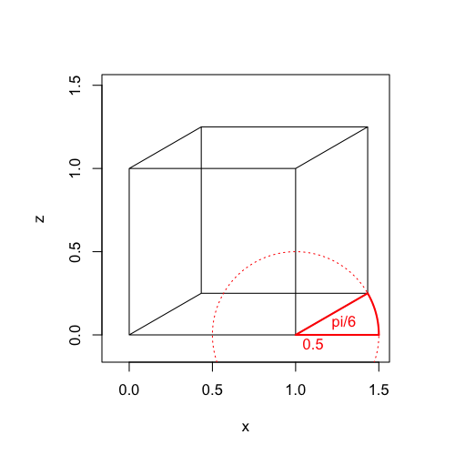

   In 3D, there are relatively simple rotation matrices for spinning around the $x$, $y$, or $z$ axis.

   $$R_x = \begin{bmatrix}1 & 0 & 0 \\ 0 & \cos(\theta_x) & -\sin(\theta_x) \\ 0 &\sin(\theta_x) & \cos(\theta_x) \end{bmatrix}$$

   $$R_y = \begin{bmatrix}\cos(\theta_y) & 0 & \sin(\theta_y) \\ 0 & 1 & 0 \\ -\sin(\theta_y) & 0 & \cos(\theta_y) \end{bmatrix}$$

   $$R_z = \begin{bmatrix}\cos(\theta_z) & -\sin(\theta_z) & 0 \\ \sin(\theta_z) & \cos(\theta_z) & 0 \\ 0 & 0 & 1\end{bmatrix}$$

## Information specific to this question

   Fill in the missing code to generate various rotations of a square pyramid.
   - Red: X1 is the original
   - Orange: X2 is after a rotation of 2.59 radians around the x-axis
   - Green: X3 has another rotation of 5.03 radians around the y-axis
   - Blue: X4 has another rotation of 3.78 radians around the z-axis

   In order to flatten the 3D points onto a 2D graph, each pyramid will undergo an oblique projection with $r=0.21$ and $\theta_P=0.55$.

   ```
   graph01 = Graphics()
   X1 = matrix([[1,-1,-1,1,1,0,1,-1,0,-1],[-1,-1,1,1,-1,0,1,1,0,-1],[-1,-1,-1,-1,-1,1,-1,-1,1,-1]])
   P = ...
   X1_flat = ...
   graph01 += line(X1_flat.transpose(),color="red")
   Rx = ...
   X2 = ...
   X2_flat = ...
   graph01 += line(X2_flat.transpose(),color="orange")
   Ry = ...
   X3 = ...
   X3_flat = ...
   graph01 += ...
   Rz = ...
   X4 = ...
   X4_flat = ...
   graph01 += ...
   show(graph01,aspect_ratio=1,axes=False)
   ```

   Which graph matches?

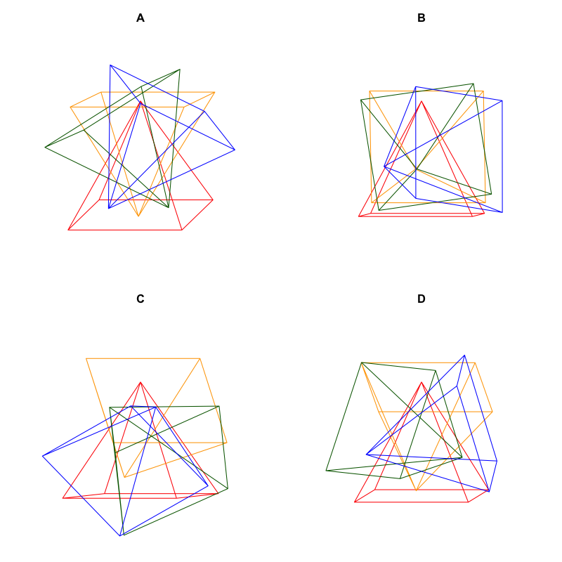

   1. A
   2. B
   3. C
   4. D

#### Question

6. One of the simplest 3D $\to$ 2D projections (to draw by hand) is an [oblique projection](https://en.wikipedia.org/wiki/Oblique_projection). Each type of oblique projection can be parameterized with an angle ($\theta$) and a ratio ($r<1$). Below is an oblique-projection matrix.

   $$P = \begin{bmatrix}1 & r\cos(\theta_P) & 0 \\ 0 & r\sin(\theta_P) & 1 \end{bmatrix}$$

   We can exemplify an oblique projection with $r=0.5$ and $\theta_P=\frac{pi}{6}$ on a unit cube. The cube has lengths 1 unit long.

   (SageMath)

   ```
   X = matrix([[0,0,0,0,0,1,1,0,1,1,0,1,1,0,1,1],[0,0,1,1,0,0,1,1,1,1,1,1,0,0,0,0],[0,1,1,0,0,0,0,0,0,1,1,1,1,1,1,0]])
   r = 0.5
   tp = pi/6
   P = matrix([[1,r*cos(tp),0],[0,r*sin(tp),1]])
   flat_X = P*X
   line(flat_X.transpose(),aspect_ratio=1)
   ```

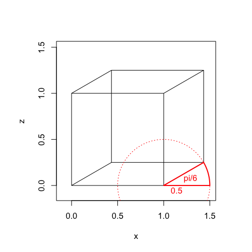

   In 3D, there are relatively simple rotation matrices for spinning around the $x$, $y$, or $z$ axis.

   $$R_x = \begin{bmatrix}1 & 0 & 0 \\ 0 & \cos(\theta_x) & -\sin(\theta_x) \\ 0 &\sin(\theta_x) & \cos(\theta_x) \end{bmatrix}$$

   $$R_y = \begin{bmatrix}\cos(\theta_y) & 0 & \sin(\theta_y) \\ 0 & 1 & 0 \\ -\sin(\theta_y) & 0 & \cos(\theta_y) \end{bmatrix}$$

   $$R_z = \begin{bmatrix}\cos(\theta_z) & -\sin(\theta_z) & 0 \\ \sin(\theta_z) & \cos(\theta_z) & 0 \\ 0 & 0 & 1\end{bmatrix}$$

## Information specific to this question

   Fill in the missing code to generate various rotations of a square pyramid.
   - Red: X1 is the original
   - Orange: X2 is after a rotation of 3.05 radians around the x-axis
   - Green: X3 has another rotation of 1.16 radians around the y-axis
   - Blue: X4 has another rotation of 4.69 radians around the z-axis

   In order to flatten the 3D points onto a 2D graph, each pyramid will undergo an oblique projection with $r=0.28$ and $\theta_P=0.41$.

   ```
   graph01 = Graphics()
   X1 = matrix([[1,-1,-1,1,1,0,1,-1,0,-1],[-1,-1,1,1,-1,0,1,1,0,-1],[-1,-1,-1,-1,-1,1,-1,-1,1,-1]])
   P = ...
   X1_flat = ...
   graph01 += line(X1_flat.transpose(),color="red")
   Rx = ...
   X2 = ...
   X2_flat = ...
   graph01 += line(X2_flat.transpose(),color="orange")
   Ry = ...
   X3 = ...
   X3_flat = ...
   graph01 += ...
   Rz = ...
   X4 = ...
   X4_flat = ...
   graph01 += ...
   show(graph01,aspect_ratio=1,axes=False)
   ```

   Which graph matches?

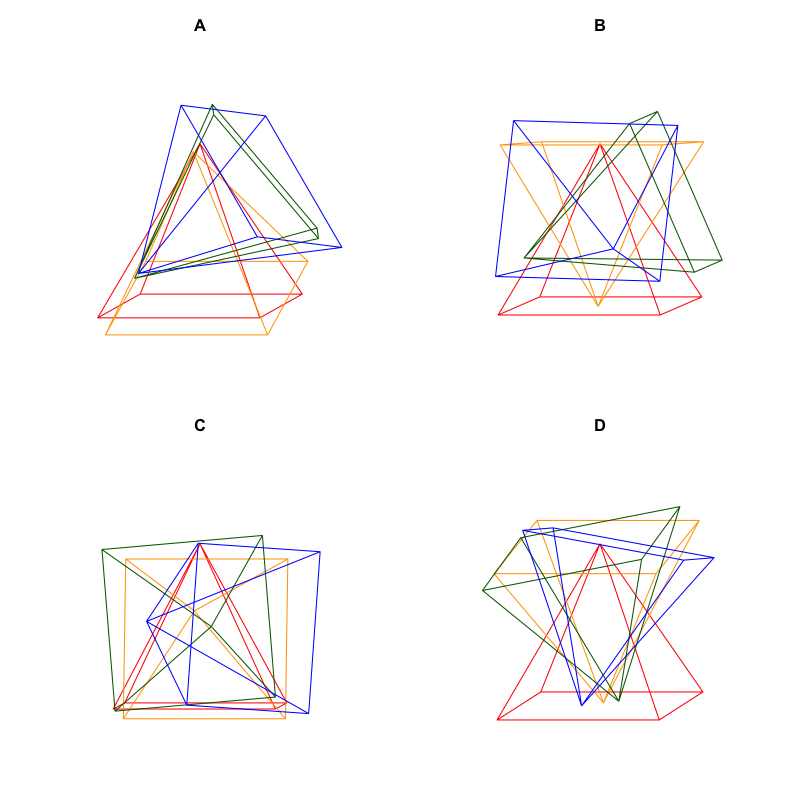

   1. A
   2. B
   3. C
   4. D

#### Question

7. One of the simplest 3D $\to$ 2D projections (to draw by hand) is an [oblique projection](https://en.wikipedia.org/wiki/Oblique_projection). Each type of oblique projection can be parameterized with an angle ($\theta$) and a ratio ($r<1$). Below is an oblique-projection matrix.

   $$P = \begin{bmatrix}1 & r\cos(\theta_P) & 0 \\ 0 & r\sin(\theta_P) & 1 \end{bmatrix}$$

   We can exemplify an oblique projection with $r=0.5$ and $\theta_P=\frac{pi}{6}$ on a unit cube. The cube has lengths 1 unit long.

   (SageMath)

   ```
   X = matrix([[0,0,0,0,0,1,1,0,1,1,0,1,1,0,1,1],[0,0,1,1,0,0,1,1,1,1,1,1,0,0,0,0],[0,1,1,0,0,0,0,0,0,1,1,1,1,1,1,0]])
   r = 0.5
   tp = pi/6
   P = matrix([[1,r*cos(tp),0],[0,r*sin(tp),1]])
   flat_X = P*X
   line(flat_X.transpose(),aspect_ratio=1)
   ```

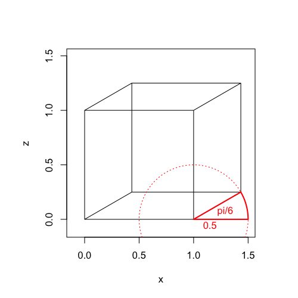

   In 3D, there are relatively simple rotation matrices for spinning around the $x$, $y$, or $z$ axis.

   $$R_x = \begin{bmatrix}1 & 0 & 0 \\ 0 & \cos(\theta_x) & -\sin(\theta_x) \\ 0 &\sin(\theta_x) & \cos(\theta_x) \end{bmatrix}$$

   $$R_y = \begin{bmatrix}\cos(\theta_y) & 0 & \sin(\theta_y) \\ 0 & 1 & 0 \\ -\sin(\theta_y) & 0 & \cos(\theta_y) \end{bmatrix}$$

   $$R_z = \begin{bmatrix}\cos(\theta_z) & -\sin(\theta_z) & 0 \\ \sin(\theta_z) & \cos(\theta_z) & 0 \\ 0 & 0 & 1\end{bmatrix}$$

## Information specific to this question

   Fill in the missing code to generate various rotations of a square pyramid.
   - Red: X1 is the original
   - Orange: X2 is after a rotation of 4.64 radians around the x-axis
   - Green: X3 has another rotation of 0.74 radians around the y-axis
   - Blue: X4 has another rotation of 5.36 radians around the z-axis

   In order to flatten the 3D points onto a 2D graph, each pyramid will undergo an oblique projection with $r=0.3$ and $\theta_P=0.52$.

   ```
   graph01 = Graphics()
   X1 = matrix([[1,-1,-1,1,1,0,1,-1,0,-1],[-1,-1,1,1,-1,0,1,1,0,-1],[-1,-1,-1,-1,-1,1,-1,-1,1,-1]])
   P = ...
   X1_flat = ...
   graph01 += line(X1_flat.transpose(),color="red")
   Rx = ...
   X2 = ...
   X2_flat = ...
   graph01 += line(X2_flat.transpose(),color="orange")
   Ry = ...
   X3 = ...
   X3_flat = ...
   graph01 += ...
   Rz = ...
   X4 = ...
   X4_flat = ...
   graph01 += ...
   show(graph01,aspect_ratio=1,axes=False)
   ```

   Which graph matches?

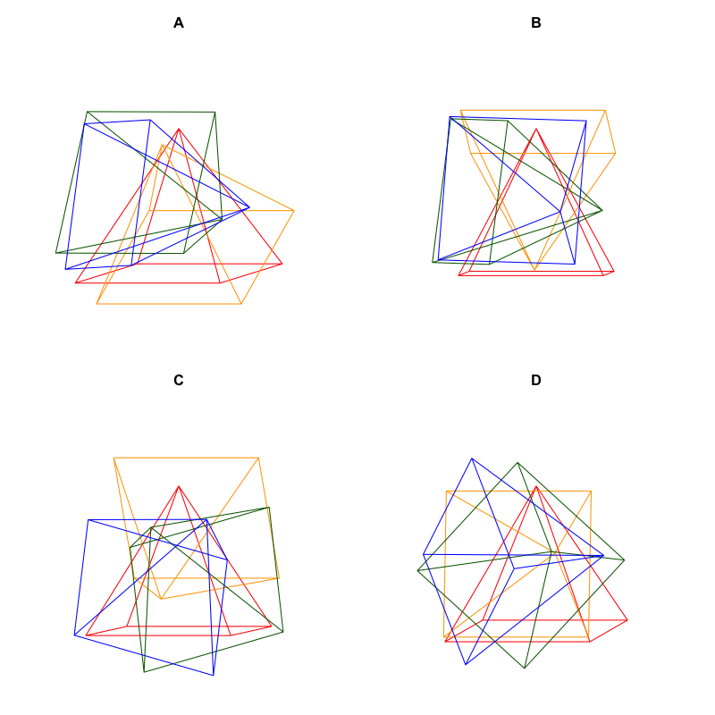

   1. A
   2. B
   3. C
   4. D

#### Question

8. One of the simplest 3D $\to$ 2D projections (to draw by hand) is an [oblique projection](https://en.wikipedia.org/wiki/Oblique_projection). Each type of oblique projection can be parameterized with an angle ($\theta$) and a ratio ($r<1$). Below is an oblique-projection matrix.

   $$P = \begin{bmatrix}1 & r\cos(\theta_P) & 0 \\ 0 & r\sin(\theta_P) & 1 \end{bmatrix}$$

   We can exemplify an oblique projection with $r=0.5$ and $\theta_P=\frac{pi}{6}$ on a unit cube. The cube has lengths 1 unit long.

   (SageMath)

   ```
   X = matrix([[0,0,0,0,0,1,1,0,1,1,0,1,1,0,1,1],[0,0,1,1,0,0,1,1,1,1,1,1,0,0,0,0],[0,1,1,0,0,0,0,0,0,1,1,1,1,1,1,0]])
   r = 0.5
   tp = pi/6
   P = matrix([[1,r*cos(tp),0],[0,r*sin(tp),1]])
   flat_X = P*X
   line(flat_X.transpose(),aspect_ratio=1)
   ```

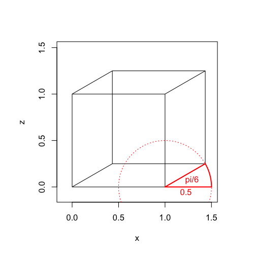

   In 3D, there are relatively simple rotation matrices for spinning around the $x$, $y$, or $z$ axis.

   $$R_x = \begin{bmatrix}1 & 0 & 0 \\ 0 & \cos(\theta_x) & -\sin(\theta_x) \\ 0 &\sin(\theta_x) & \cos(\theta_x) \end{bmatrix}$$

   $$R_y = \begin{bmatrix}\cos(\theta_y) & 0 & \sin(\theta_y) \\ 0 & 1 & 0 \\ -\sin(\theta_y) & 0 & \cos(\theta_y) \end{bmatrix}$$

   $$R_z = \begin{bmatrix}\cos(\theta_z) & -\sin(\theta_z) & 0 \\ \sin(\theta_z) & \cos(\theta_z) & 0 \\ 0 & 0 & 1\end{bmatrix}$$

## Information specific to this question

   Fill in the missing code to generate various rotations of a square pyramid.
   - Red: X1 is the original
   - Orange: X2 is after a rotation of 5.21 radians around the x-axis
   - Green: X3 has another rotation of 5.31 radians around the y-axis
   - Blue: X4 has another rotation of 2.48 radians around the z-axis

   In order to flatten the 3D points onto a 2D graph, each pyramid will undergo an oblique projection with $r=0.45$ and $\theta_P=0.36$.

   ```
   graph01 = Graphics()
   X1 = matrix([[1,-1,-1,1,1,0,1,-1,0,-1],[-1,-1,1,1,-1,0,1,1,0,-1],[-1,-1,-1,-1,-1,1,-1,-1,1,-1]])
   P = ...
   X1_flat = ...
   graph01 += line(X1_flat.transpose(),color="red")
   Rx = ...
   X2 = ...
   X2_flat = ...
   graph01 += line(X2_flat.transpose(),color="orange")
   Ry = ...
   X3 = ...
   X3_flat = ...
   graph01 += ...
   Rz = ...
   X4 = ...
   X4_flat = ...
   graph01 += ...
   show(graph01,aspect_ratio=1,axes=False)
   ```

   Which graph matches?

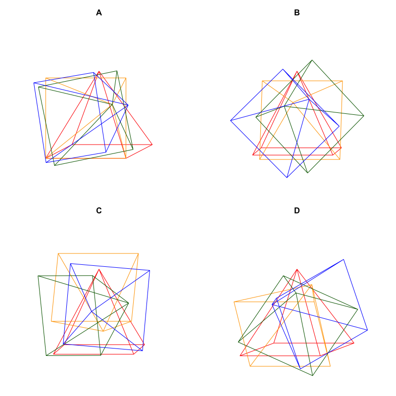

   1. A
   2. B
   3. C
   4. D